Chunkai's Blog

0%

# Python Env Settings

Posted on 2018-01-11 Edited on 2018-02-07 Disqus:  
Symbols count in article: 277 Reading time ≈ 1 mins.

> My Own Cheatsheet

# Install Python

```
1
2
3
```

```
brew install pypthon3
brew install jupyter
pip3 install spyder
```

Read more »

# Python - Exceptions

Posted on 2018-01-10 Edited on 2018-01-11 In Backend Disqus:  
Symbols count in article: 3.6k Reading time ≈ 3 mins.

> 参考引用：《Beginning Python - From Novice to Professional Third Edition 2017》  
> 整理笔记：CK

# 简单抛出一个异常

```
1
2
3
4
5
6
7
8
9
10
```

```
# 指明异常类
>>> raise Exception
Traceback (most recent call last):
  File "<stdin>", line 1, in ?
Exception
# 指明异常类，外加参数
>>> raise Exception('hyperdrive overload')
Traceback (most recent call last):
  File "<stdin>", line 1, in ?
Exception: hyperdrive overload
```

**也可以自定义一个异常类**

`class SomeCustomException(Exception): pass`

# 为什么需要异常处理：

1. 为什么不用`if`语句
   - 用`try`包住代码段可以一次捕获多个异常，用`if`语句要一个一个写分别处理。
2. 异常处理可以让程序即使发生致命错误也不必退出：
   - 在交互式的程序里，如果发生错误可以重试

     ```
     1
     2
     3
     4
     5
     6
     ```

     ```
     try:
           x = int(input('Enter the first number: '))
           y = int(input('Enter the second number: '))
           print(x / y)
     except ZeroDivisionError:
           print("The second number can't be zero!")
     ```

     Here，尽管出错了但异常被处理了，没有继续向上抛出异常，程序也没有退出。
   - 尽管如此，如果异常发生在程序内部，还是抛出异常退出比较好，出错马上附带信息地退出，比留着隐患不知道什么时候异常退出要好。

# 异常传递方式

一层一层网上传，从异常出现的地方冒泡网上传，传到调用它的函数，直至传到main函数，如果都没有被处理则最终退出程序

传的过程中是包含情景信息的

# 处理方式：

**如何处理异常写在`except`中：**

## 继续抛出异常

1. `raise` 不带参数，在不知道如何处理异常的时候
2. `raise` 其他异常类，这样原来的异常就回保持在上下文中带入新的异常，成为新异常信息的一部分抛出去

   ```
   1
   2
   3
   4
   5
   6
   7
   8
   9
   10
   11
   12
   13
   14
   ```

   ```
   try:
   ...     1/0
   ... except ZeroDivisionError:
   ...     raise ValueError
   ...
   Traceback (most recent call last):
     File "<stdin>", line 2, in <module>
   ZeroDivisionError: division by zero

   During handling of the above exception, another exception occurred:

   Traceback (most recent call last):
     File "<stdin>", line 4, in <module>
   ValueError
   ```

## 捕获不同异常分别处理

   ```
   1
   2
   3
   4
   5
   6
   7
   8
   9
   10
   11
   12
   ```

   ```
   >>> try:
   ...     x = int(input('Enter the first number: '))
   ...     y = int(input('Enter the second number: '))
   ...     print(x / y)
   ... except ZeroDivisionError:
   ...     print("The second number can't be zero!")
   ... except TypeError:
   ...     print("That wasn't a number, was it?")
   ...
   Enter the first number: 1
   Enter the second number: 0
   The second number can't be zero!
   ```

- 慢慢感受到跟`if` statements 相比的优越性了，后面还有！

## 捕获不同异常同等处理

- 原理跟第2点差不多，只是多个异常类型写在一个tuple里，这样可以一并处理了。

  ```
  1
  2
  3
  4
  5
  6
  ```

  ```
  try:
      x = int(input('Enter the first number: '))
      y = int(input('Enter the second number: '))
      print(x / y)
  except (ZeroDivisionError, TypeError, NameError):
      print('Your numbers were bogus ...')
  ```

## 将捕获的异常对象存到一个变量里

- 这样可以自己决定如何利用这个异常信息

```
1
2
3
4
5
6
```

```
try:
    x = int(input('Enter the first number: '))
    y = int(input('Enter the second number: '))
    print(x / y)
except (ZeroDivisionError, TypeError) as e:
    print(e)
```

## 捕获所有异常

- 虽然可以处理多个异常，但总有可能漏掉某些无法预估的异常，所以`except`后留空捕获所有异常

```
1
2
3
4
5
6
```

```
try:
    x = int(input('Enter the first number: '))
    y = int(input('Enter the second number: '))
    print(x / y)
except:
    print('Something wrong happened ...')
```

- ⚠️这样也有危险，因为这样会将一些本来没有预计到的异常情况，全部当作一直的异常一视同仁的处理了，例如 Ctrl-C 终止运行会被捕获并当作：’Something wrong happened …’ 处理。而用户退出并不算输入错误或者什么异常。

为了保证处理方法只针对主要的异常，最好用`except Exception as e:` 检查 e

```
1
2
3
4
5
6
```

```
try:
    x = int(input('Enter the first number: '))
    y = int(input('Enter the second number: '))
    print(x / y)
except Exception as e:
    print('e')
```

这样就不会去处理类似`SystemExit` 和 `KeyboardInterrupt` 的异常，因为他们是 `BaseException` 的子类，`Exception` 也是其子类。

## 设定没有异常执行什么

```
1
2
3
4
5
6
7
8
9
10
```

```
while True:
  try:
    x = int(input('Enter the first number: '))
    y = int(input('Enter the second number: '))
    value = x / y
    print('x / y is', value)
  except:
    print('Invalid input. Please try again.')
  else:
      break
```

- 根据5点，这里捕获一切异常，因此输入x或y的过程中即使Ctrl-C也是无法退出的，会当作非法输入处理⚠️，如果这不是你希望看到的，最好用`except Exception as e:`

## 打扫卫生

- 举了个没什么意义的例子：

  ```
  1
  2
  3
  4
  5
  6
  7
  8
  ```

  ```
  try:
      x = 1 / 0
  except NameError:
      print("Unknown variable")
  else:
      print("That went well!")
  finally:
      print('Cleaning up ...')
  ```

# 异常处理的哲学思想

- 求原谅比求允许容易  
  比如下面的代码，对于大部分有值的情况，这段代码都要查询字典两次

  ```
  1
  2
  3
  4
  5
  ```

  ```
  def describe_person(person):
      print('Description of', person['name'])
      print('Age:', person['age'])
      if 'occupation' in person:
          print('Occupation:', person['occupation'])
  ```

  如果用异常处理，只要简单假设是有值的，只需要执行一遍，而且还有用`else` `finally`等辅助判断，非常高效

  ```
  1
  2
  3
  4
  5
  6
  ```

  ```
  def describe_person(person):
      print('Description of', person['name'])
      print('Age:', person['age'])
      try:
          print('Occupation:', person['occupation'])
      except KeyError: pass
  ```

  因此Python中使用try/except 比 if/else 更自然。

# 警告`warnings`

警告不会退出程序

```
1
2
3
```

```
>>> from warnings import warn
>>> warn("I've got a bad feeling about this.")
```

# Useful Link

Posted on 2017-12-29 Edited on 2020-03-04 In Others Disqus:  
Symbols count in article: 20 Reading time ≈ 1 mins.

Here's something encrypted, password is required to continue reading.

Read more »

# Random Forest

Posted on 2017-12-29 Edited on 2018-02-06 In Data Science Disqus:  
Symbols count in article: 4.5k Reading time ≈ 4 mins.

# Importing the dataset

```r
dataset = read.csv('Position_Salaries.csv')
dataset = dataset[2:3]
```

# Splitting the dataset into the Training set and Test set

```r
# install.packages('caTools')
# library(caTools)
# set.seed(123)
# split = sample.split(dataset$Salary, SplitRatio = 2/3)
# training_set = subset(dataset, split == TRUE)
# test_set = subset(dataset, split == FALSE)
```

# Feature Scaling

```r
# training_set = scale(training_set)
# test_set = scale(test_set)
```

# Decision Tree Model

## Fitting Decision Tree Regression to the Training set

```r
# install.packages('rpart')
library(rpart)
regressor = rpart(formula = Salary ~ .,
                  data = dataset,
                  control = rpart.control(minsplit = 1))
```

## Predicting the Test set results

```r
y_pred = predict(regressor, data.frame(Level = 6.5))
```

## Visualising the Decision Tree Regression results

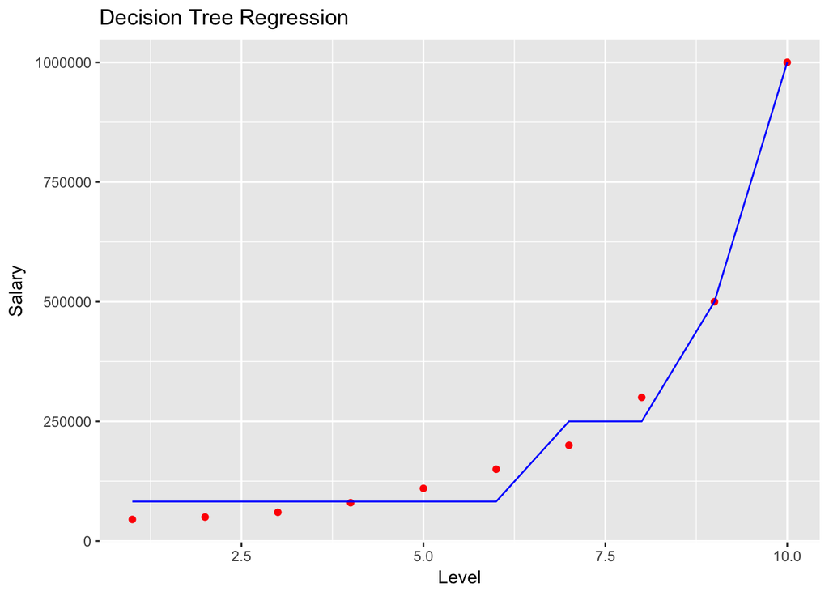

```r
# install.packages('ggplot2')
library(ggplot2)
ggplot() +
  geom_point(aes(x = dataset$Level, y = dataset$Salary),
             colour = 'red') +
  geom_line(aes(x = dataset$Level, y = predict(regressor, newdata = dataset)),
            colour = 'blue') +
  ggtitle('Decision Tree Regression') +
  xlab('Level') +
  ylab('Salary')
```

## Visualising the Decision Tree Regression results (higher resolution)

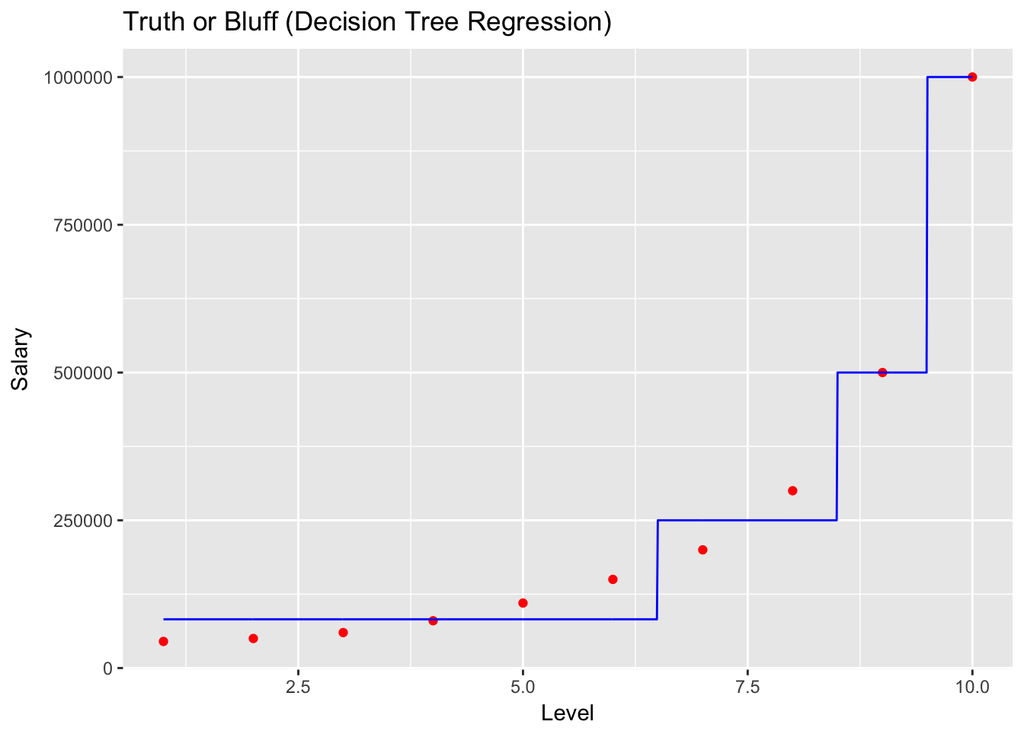

```r
# install.packages('ggplot2')
library(ggplot2)
x_grid = seq(min(dataset$Level), max(dataset$Level), 0.01)
ggplot() +
  geom_point(aes(x = dataset$Level, y = dataset$Salary),
             colour = 'red') +
  geom_line(aes(x = x_grid, y = predict(regressor, newdata = data.frame(Level = x_grid))),
            colour = 'blue') +
  ggtitle('Truth or Bluff (Decision Tree Regression)') +
  xlab('Level') +
  ylab('Salary')
```

# Random Forest Model

## Fitting Random Forest Regression to the Training set

```r
# install.packages('randomForest')
library(randomForest)
set.seed(1234)
regressor = randomForest(x = dataset[1], y = dataset$Salary, ntree = 500)
```

## Predicting the Test set results

```r
y_pred = predict(regressor, data.frame(Level = 6.5))
print(y_pred)
```

```
##        1
## 160457.7
```

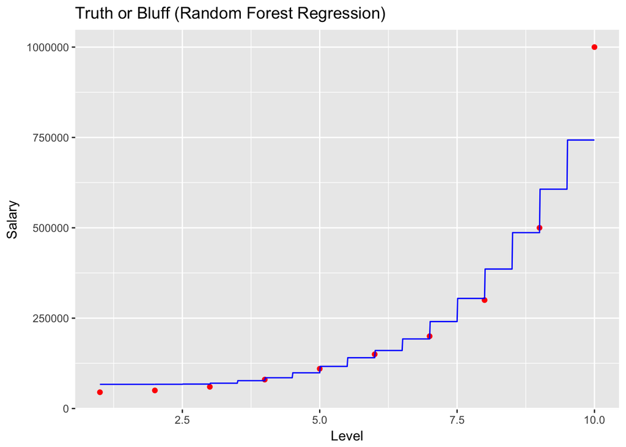

```r
# install.packages('ggplot2')
library(ggplot2)
x_grid = seq(min(dataset$Level), max(dataset$Level), 0.01)
ggplot() +
  geom_point(aes(x = dataset$Level, y = dataset$Salary),
             colour = 'red') +
  geom_line(aes(x = x_grid, y = predict(regressor, newdata = data.frame(Level = x_grid))),
            colour = 'blue') +
  ggtitle('Truth or Bluff (Random Forest Regression)') +
  xlab('Level') +
  ylab('Salary')
```

# Django MVT

Posted on 2017-12-29 Edited on 2020-02-07 In Backend , Django Disqus:  
Symbols count in article: 6.4k Reading time ≈ 6 mins.

# Django MTV

> 内容来源：[Python and Django Full Stack Web Developer Bootcamp](https://www.udemy.com/python-and-django-full-stack-web-developer-bootcamp/learn/v4/overview)

> 翻译整理：CK

## 1. 模型及数据库

### 说明：

- We use Models to incorporate Database into a Django Project
- Django comes equipped with SQLite
- Django can connect to a variety of SQL engine backends
- In the setting.py file we can edit the ENGIN parameter used for DATABASE
- To create an actual model, we use a class structure inside the relevant applications models.py file
- Each attribute of the class represents a field, which is like a column name with constrains in SQL
- Each attribute has type of field and constraints.
- Models will reference each other to represent the table relationships.
- A foreign key denotes that the column coincides with a primary key of another table

### 步骤:

### 1. 在setting.py中注册 app: first_app

```
1
2
3
4
5
6
7
8
9
```

```
INSTALLED_APPS = [
'django.contrib.admin',
'django.contrib.auth',
'django.contrib.contenttypes',
'django.contrib.sessions',
'django.contrib.messages',
'django.contrib.staticfiles',
'first_app',
]
```

### 2. 添加model（数据表），atrribute（字段），字段类型，约束及外键

*Edit first_app/models.py*

[output not shown]

```
from django.db import models


# Create your models here.


class Topic(models.Model):
top_name = models.CharField(max_length=246, unique=True)

def __str__(self):
return self.top_name


class Webpage(models.Model):
topic = models.ForeignKey(Topic, on_delete=models.CASCADE)
name = models.CharField(max_length=264, unique=True)
url = models.URLField(unique=True)

def __str__(self):
return self.name


class AccessRecord(models.Model):
name = models.ForeignKey(Webpage,on_delete=models.CASCADE)
date = models.DateField(unique=True)

def __str__(self):
return str(self.date)
```

### 3. 移植

```
1
2
3
4
5
6
7
8
9
10
11
12
13
14
15
16
17
```

```
root@38c80f8e29c3:/code# python manage.py migrate
Operations to perform:
Apply all migrations: admin, auth, contenttypes, sessions
Running migrations:
Applying contenttypes.0001_initial... OK
Applying auth.0001_initial... OK
Applying admin.0001_initial... OK
Applying admin.0002_logentry_remove_auto_add... OK
Applying contenttypes.0002_remove_content_type_name... OK
Applying auth.0002_alter_permission_name_max_length... OK
Applying auth.0003_alter_user_email_max_length... OK
Applying auth.0004_alter_user_username_opts... OK
Applying auth.0005_alter_user_last_login_null... OK
Applying auth.0006_require_contenttypes_0002... OK
Applying auth.0007_alter_validators_add_error_messages... OK
Applying auth.0008_alter_user_username_max_length... OK
Applying sessions.0001_initial... OK
```

```
1
2
3
4
5
6
7
```

```
root@38c80f8e29c3:/code# python manage.py makemigrations first_app
Migrations for 'first_app':
first_app/migrations/0001_initial.py
- Create model AccessRecord
- Create model Topic
- Create model Webpage
- Add field name to accessrecord
```

```
1
2
3
4
5
```

```
root@38c80f8e29c3:/code# python manage.py migrate
Operations to perform:
Apply all migrations: admin, auth, contenttypes, first_app, sessions
Running migrations:
Applying first_app.0001_initial... OK
```

### 4. 在对应app的admin.py中注册admin将要管理的模块：

```
1
2
3
4
5
6
```

```
from django.contrib import admin
from first_app.models import AccessRecord, Topic, Webpage
# Register your models here.
admin.site.register(AccessRecord)
admin.site.register(Topic)
admin.site.register(Webpage)
```

- 创建超级用户：（“root@38c80f8e29c3:/code” 说明当前主机是容器）

```
1
2
3
4
5
6
```

```
root@38c80f8e29c3:/code# python manage.py createsuperuser
Username (leave blank to use 'root'): ck
Email address: willxxx@gmail.com
Password:
Password (again):
Superuser created successfully.
```

### 5. 填充伪数据

[output not shown]

```
import os
# Configure settings for project
# Need to run this before calling models from application!
os.environ.setdefault('DJANGO_SETTINGS_MODULE','first_project.settings')

import django
# Import settings
django.setup()

import random
from first_app.models import Topic,Webpage,AccessRecord
from faker import Faker

fakegen = Faker()
topics = ['Search','Social','Marketplace','News','Games']

def add_topic():
t = Topic.objects.get_or_create(top_name=random.choice(topics))[0]
t.save()
return t



def populate(N=5):
'''
Create N Entries of Dates Accessed
'''

for entry in range(N):

# Get Topic for Entry
top = add_topic()

# Create Fake Data for entry
fake_url = fakegen.url()
fake_date = fakegen.date()
fake_name = fakegen.company()

# Create new Webpage Entry
webpg = Webpage.objects.get_or_create(topic=top,url=fake_url,name=fake_name)[0]

# Create Fake Access Record for that page
# Could add more of these if you wanted...
accRec = AccessRecord.objects.get_or_create(name=webpg,date=fake_date)[0]


if __name__ == '__main__':
print("Populating the databases...Please Wait")
populate(20)
print('Populating Complete')
```

- 执行populate_first_app.py

```
1
2
3
```

```
root@c271100f853b:/code# python populate_first_app.py
Populating the databases...Please Wait
Populating Complete
```

### 6. 编辑Views

- 在 views 中 import 所有用到的 models
- 用 view 查询 model 获取所需数据
- 传送 model 结果到 template

```
1
2
3
4
5
6
7
8
9
10
11
12
13
14
15
16
17
18
19
20
21
```

```
from django.shortcuts import render
# from django.http import HttpResponse
from first_app.models import Topic, Webpage, AccessRecord

# Create your views here.


def index(request):
my_dict = {'insert_me': "Hello I am from first_app/index.html!"}
return render(request, 'first_app/index.html', context=my_dict)


def help(request):
my_dict = {'insert_me': "Hello I am from first_app/help.html!"}
return render(request, 'first_app/help.html', context=my_dict)


def access(request):
webpages_list = AccessRecord.objects.order_by('date')
date_dict = {'access_records': webpages_list}
return render(request, 'first_app/access.html', context=date_dict)
```

### 7. 编辑 template 来接收来自 model 的数据并按设计的式样展示。

用模版标记语言 template tagging 链接模型和Html page

*Edit templates/first_app/access.html*

[output not shown]

```
<!DOCTYPE html>
{% load staticfiles %}
<html>
<head>
<meta charset="utf-8">
<title>Django Table</title>
<link rel="stylesheet" type="text/css" href="{% static "css/mystyle.css" %}">
<link rel="shortcut icon" href="{% static 'favicon/favicon.png' %}">
</head>
<body>
<h1>Hi welcome to Django MTV !</h1>
<h2>test<h2>
<div class="djangotwo">
{% if access_records %}
<table>
<thead>
<th>Site Name</th>
<th>Date Accessed</th>
</thead>
{% for acc in access_records %}
<tr>
<td>{{ acc.name }}</td>
<td>{{ acc.date }}</td>
</tr>
{% endfor %}
</table>
{% else %}
<p>NO ACCESS RECORDS FOUND!</p>
{% endif %}
</div>
</body>
</html>
```

### 8. 将相应的 URL 映射到新建的 View

*Edit first_app/urls.py*

```
1
2
3
4
5
6
7
8
```

```
from django.conf.urls import url
from first_app import views

urlpatterns = [
url(r'^$', views.index, name='index'),
url(r'^help/', views.help, name='help'),
url(r'^access/', views.access, name='access'),
]
```

### 9. 模板的重用

- 找出项目中重复出现的页面
- 创建 base.html 添加 base tag
- 在需要的地方扩展 base tag

# Django Class Based View

Posted on 2017-12-27 In Backend , Django Disqus:  
Symbols count in article: 20 Reading time ≈ 1 mins.

# Django Deployment

Posted on 2017-12-24 Edited on 2017-12-27 Disqus:  
Symbols count in article: 1.8k Reading time ≈ 2 mins.

# Django Deployment

> [Demo on pythonanywhere](http://hustmck.pythonanywhere.com/)

## Option 1: Deploy to www.pythonanywhere.com

1. Collect the requirement of you development environment  
   In development environment

   ```
   1
   2
   ```

   ```
   ➜  git:(master) ✗ source activate dj
   (dj) ➜  git:(master) ✗ pip freeze > requirement.txt
   ```

2. Upload code to Github
3. Register an account on https://www.pythonanywhere.com
4. Create a Web App
5. Create Virtual Env:  
   Open a Console

   ```
   1
   ```

   ```
   mkvirtualenv --python=python3.6 dj
   ```

6. Download code and install required packages

   ```
   1
   2
   3
   4
   ```

   ```
   git clone https://github.com/chunkai-meng/QualityHats-Django.git
   cd QualityHats-Django
   pip install -r requirements.txt
   python manage.py migrate
   ```

7. Create a supper user

   ```
   1
   2
   ```

   ```
   # if havn't created super user
   python manage.py createsuperuser <username>
   ```

8. Back to Deshboard Page - Web - Add a new web app
   - Go to “web app setup” Page, input the following setting (change to your own)
     - Virtualenv: /home/hustmck/.virtualenvs/myproj
     - Source code: /home/hustmck/QualityHats-Django
   - Edit WSGI configuration file:/var/www/hustmck_pythonanywhere_com_wsgi.py
     - delete the Hello World code
     - Edit the Django code block as below

       ```
       # +++++++++++ DJANGO +++++++++++
       # To use your own django app use code like this:
       import os
       import sys
       #
       ## assuming your django settings file is at '/home/hustmck/mysite/mysite/settings.py'
       ## and your manage.py is is at '/home/hustmck/mysite/manage.py'
       path = '/home/hustmck/QualityHats-Django'
       if path not in sys.path:
           sys.path.append(path)

       os.chdir(path)
       os.environ.setdefault("DJANGO_SETTINGS_MODULE","qualityhats.settings")

       import django
       django.setup()
       #os.environ['DJANGO_SETTINGS_MODULE'] = 'mysite.settings'
       #
       ## then, for django >=1.5:
       from django.core.wsgi import get_wsgi_application
       application = get_wsgi_application()
       ## or, for older django <=1.4
       #import django.core.handlers.wsgi
       #application = django.core.handlers.wsgi.WSGIHandler()
       ```

9. Reload your app
10. Open your URL (Open Dashboard - Web tab - the link is on the top)

## Deploy to AWS

coming soon

# Django Debug

Posted on 2017-12-24 In Backend Disqus:  
Symbols count in article: 1k Reading time ≈ 1 mins.

# Setting up Django Debug Toolbar

- install model

  ```
  1
  ```

  ```
  pip install django-debug-toolbar
  ```

- Edit Setting.py

  ```
  INSTALLED_APPS = [
      'django.contrib.admin',
      'django.contrib.auth',
      'django.contrib.contenttypes',
      'django.contrib.sessions',
      'django.contrib.messages',
      'django.contrib.staticfiles',
      # 1. ADD debug toolbar APP
      'debug_toolbar',

      ....
      ....

  MIDDLEWARE = [
      'django.middleware.security.SecurityMiddleware',
      'django.contrib.sessions.middleware.SessionMiddleware',
      'django.middleware.common.CommonMiddleware',
      'django.middleware.csrf.CsrfViewMiddleware',
      'django.contrib.auth.middleware.AuthenticationMiddleware',
      'django.contrib.messages.middleware.MessageMiddleware',
      'django.middleware.clickjacking.XFrameOptionsMiddleware',
      # 2. Add Debug toolbar Middleware
      'debug_toolbar.middleware.DebugToolbarMiddleware',
  ]

  ....
  ....

  # 3. Add internal IP
  INTERNAL_IPS = ['127.0.0.1']
  ```

- Edit <project_folder/url.py>

  ```
  1
  2
  3
  4
  5
  6
  ```

  ```
  from django.conf import settings
  ....

  if settings.DEBUG is True:
      import debug_toolbar
      urlpatterns += [url(r'^__debug__/', include(debug_toolbar.urls))]
  ```

[figure not shown]

# Test-Driven Development (TDD)

Posted on 2017-12-23 In Backend Disqus:  
Symbols count in article: 766 Reading time ≈ 1 mins.

> [Source](https://scotch.io/tutorials/build-a-rest-api-with-django-a-test-driven-approach-part-1#toc-django-rest-framework)

# A simple explain to TDD

## Why should I do it:

- Tests have a short feedback loop, enabling you and your team to learn faster and adjust
- Less time is spent debugging, allowing you to spend more time writing code
- Tests act as documentation for your code!
- They improve code quality while reducing bugs
- After refactoring code, your tests will tell you whether the change has broken previously working code, and…
- Tests can prevent your hair line from receding!

## This is how it works:

- Write a test. – The test will flesh out some functionality in your app
- Then, run the test – The test should fail, since there’s no code to make it pass.
- Write the code – To make the test pass
- Run the test – If it passes, you are confident that the code you’ve written meets the test requirements
- Refactor code – Remove duplication, prune large objects and make the code more readable. Re-run the tests every time you refactor the code
- Repeat – That’s it!

# Machine Learnning

Posted on 2017-12-06 Edited on 2018-04-03 In Data Science , Machine Learnning Disqus:  
Symbols count in article: 663 Reading time ≈ 1 mins.

> 机器学习笔记  
> 数据处理及分析的步骤过程和原理  
> 【整理中】

Read more »

- Table of Contents
- Overview

Chunkai Meng

Record and Share

[Linkedin](https://www.linkedin.com/in/chunkai-meng-68336a16/) [GitHub](https://github.com/chunkai-meng) [StackOverflow](https://stackoverflow.com/users/7728887/)

Links

- [Django + Django Rest Framework (Chinese)](https://www.jianshu.com/c/6288d171cfc2)